# Lab 3a

```r
library(tidyverse)
```

```r
 download.file(url="https://ndownloader.figshare.com/files/2292169",
              destfile = "portal_data_joined.csv")
```

```r
surveys <- read.csv("portal_data_joined.csv")
```

## Challenge_1

Based on the output of str(surveys), can you answer the following questions. 1. What is the class of the object surveys?

Data frame

```r
str(surveys)
```

```
## 'data.frame':    34786 obs. of  13 variables:
##  $ record_id      : int  1 72 224 266 349 363 435 506 588 661 ...
##  $ month          : int  7 8 9 10 11 11 12 1 2 3 ...
##  $ day            : int  16 19 13 16 12 12 10 8 18 11 ...
##  $ year           : int  1977 1977 1977 1977 1977 1977 1977 1978 1978 1978 ...
##  $ plot_id        : int  2 2 2 2 2 2 2 2 2 2 ...
##  $ species_id     : chr  "NL" "NL" "NL" "NL" ...
##  $ sex            : chr  "M" "M" "" "" ...
##  $ hindfoot_length: int  32 31 NA NA NA NA NA NA NA NA ...
##  $ weight         : int  NA NA NA NA NA NA NA NA 218 NA ...
##  $ genus          : chr  "Neotoma" "Neotoma" "Neotoma" "Neotoma" ...
##  $ species        : chr  "albigula" "albigula" "albigula" "albigula" ...
##  $ taxa           : chr  "Rodent" "Rodent" "Rodent" "Rodent" ...
##  $ plot_type      : chr  "Control" "Control" "Control" "Control" ...
```

2a. How many columns are in this object?

```r
ncol(surveys)
```

```
## [1] 13
```

2b. How many rows are in this object?

```r
nrow(surveys)
```

```
## [1] 34786
```

3. How many species have been recorded during these surveys?

```r
surveys$species_id <- factor(surveys$species_id)
```

```r
length(summary(surveys[ , "species_id"]))
```

```
## [1] 48
```

## Challenge_2

1. Create a data.frame (surveys_200) containing only the data in row 200 of the surveys dataset.

```r
surveys_200 <- surveys[200, ]
```

2. Notice how nrow() gave you the number of rows in a data.frame?

2a. Use that number to pull out just that last row in the data frame.

```r
n_rows <- nrow(surveys)
```

```r
surveys_last <- surveys[n_rows, ]
surveys_last
```

```
##       record_id month day year plot_id species_id sex hindfoot_length weight
## 34786     30986     7   1 2000       7         PX                  NA     NA
##             genus species   taxa        plot_type
## 34786 Chaetodipus     sp. Rodent Rodent Exclosure
```

2b. Compare that with what you see as the last row using tail() to make sure it’s meeting expectations.

```r
tail(surveys)
```

```
##       record_id month day year plot_id species_id sex hindfoot_length weight
## 34781     26787     9  27 1997       7         PL   F              21     16
## 34782     26966    10  25 1997       7         PL   M              20     16
## 34783     27185    11  22 1997       7         PL   F              21     22
## 34784     27792     5   2 1998       7         PL   F              20      8
## 34785     28806    11  21 1998       7         PX                  NA     NA
## 34786     30986     7   1 2000       7         PX                  NA     NA
##             genus  species   taxa        plot_type
## 34781  Peromyscus leucopus Rodent Rodent Exclosure
## 34782  Peromyscus leucopus Rodent Rodent Exclosure
## 34783  Peromyscus leucopus Rodent Rodent Exclosure
## 34784  Peromyscus leucopus Rodent Rodent Exclosure
## 34785 Chaetodipus      sp. Rodent Rodent Exclosure
## 34786 Chaetodipus      sp. Rodent Rodent Exclosure
```

2c. Pull out that last row using nrow() instead of the row number.

```r
nrow(surveys)
```

```
## [1] 34786
```

2d. Create a new data frame (surveys_last) from that last row.

```r
surveys_last <- surveys[n_rows, ]
```

3. Use nrow() to extract the row that is in the middle of the data frame. Store the content of this row in an object named surveys_middle.

```r
surveys_middle <- surveys[n_rows / 2, ]
surveys_middle
```

```
##       record_id month day year plot_id species_id sex hindfoot_length weight
## 17393      9828     1  19 1985      14         AB                  NA     NA
##            genus   species taxa plot_type
## 17393 Amphispiza bilineata Bird   Control
```

4. Combine nrow() with the - notation above to reproduce the behavior of head(surveys), keeping just the first through 6th rows of the surveys dataset.

```r
surveys_head <- surveys[-(7:n_rows), ]
```

## Challenge_3

1. Rename “F” and “M” to “female” and “male” respectively.

```r
sex <- factor(surveys$sex)
```

```r
levels(sex)[2:3] <- c("female", "male")
```

```r
sex <- factor(sex, levels = c("female", "male", "undetermined"))
```

2. Now that we have renamed the factor level to “undetermined”, can you recreate the barplot such that “undetermined” is last (after “male”)?

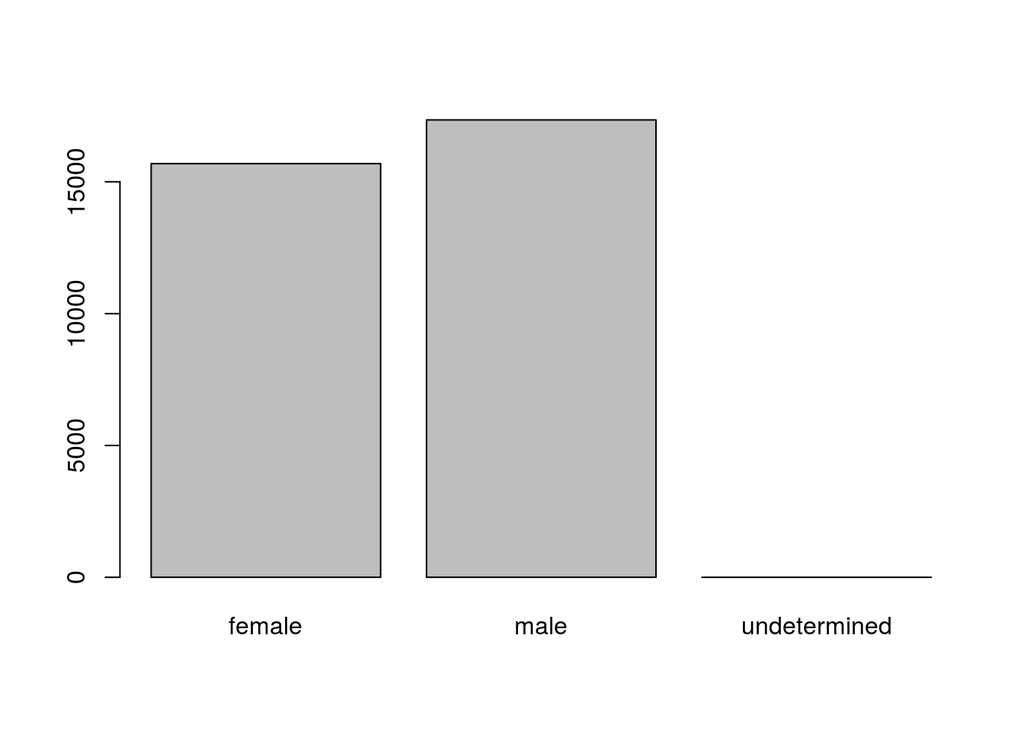

```r
plot(sex)
```

```r
str(surveys)
```

```
## 'data.frame':    34786 obs. of  13 variables:
##  $ record_id      : int  1 72 224 266 349 363 435 506 588 661 ...
##  $ month          : int  7 8 9 10 11 11 12 1 2 3 ...
##  $ day            : int  16 19 13 16 12 12 10 8 18 11 ...
##  $ year           : int  1977 1977 1977 1977 1977 1977 1977 1978 1978 1978 ...
##  $ plot_id        : int  2 2 2 2 2 2 2 2 2 2 ...
##  $ species_id     : Factor w/ 48 levels "AB","AH","AS",..: 16 16 16 16 16 16 16 16 16 16 ...
##  $ sex            : chr  "M" "M" "" "" ...
##  $ hindfoot_length: int  32 31 NA NA NA NA NA NA NA NA ...
##  $ weight         : int  NA NA NA NA NA NA NA NA 218 NA ...
##  $ genus          : chr  "Neotoma" "Neotoma" "Neotoma" "Neotoma" ...
##  $ species        : chr  "albigula" "albigula" "albigula" "albigula" ...
##  $ taxa           : chr  "Rodent" "Rodent" "Rodent" "Rodent" ...
##  $ plot_type      : chr  "Control" "Control" "Control" "Control" ...
```

## Challenge_4

1. We have seen how data frames are created when using read.csv(), but they can also be created by hand with the data.frame() function. There are a few mistakes in this hand-crafted data.frame. Can you spot and fix them? Don’t hesitate to experiment!

animal_data <- data.frame( animal = c(dog, cat, sea cucumber, sea urchin), feel = c(“furry”, “squishy”, “spiny”), weight = c(45, 8 1.1, 0.8) )

```r
animal_data <- data.frame(
          animal = c("dog", "cat", "sea cucumber", "sea urchin"),
          feel = c("furry", "furry", "squishy", "spiny"),
          weight = c(45, 8, 1.1, 0.8)
)
```

2. Can you predict the class for each of the columns in the following example? Check your guesses using str(country_climate):

2a. Are they what you expected? Why? Why not?

```r
country_climate <- data.frame(
       country = c("Canada", "Panama", "South Africa", "Australia"),
       climate = c("cold", "hot", "temperate", "hot/temperate"),
       temperature = c(10, 30, 18, "15"),
       northern_hemisphere = c(TRUE, TRUE, FALSE, "FALSE"),
       has_kangaroo = c(FALSE, FALSE, FALSE, 1)
       )
```

```r
str(country_climate)
```

```
## 'data.frame':    4 obs. of  5 variables:
##  $ country            : chr  "Canada" "Panama" "South Africa" "Australia"
##  $ climate            : chr  "cold" "hot" "temperate" "hot/temperate"
##  $ temperature        : chr  "10" "30" "18" "15"
##  $ northern_hemisphere: chr  "TRUE" "TRUE" "FALSE" "FALSE"
##  $ has_kangaroo       : num  0 0 0 1
```

2b. What would have been different if we had added stringsAsFactors = FALSE when creating the data frame?

stringsAsFactors = FALSE would have made character vectors instead of factors. stringsAsFactors = TRUE would make them factors, shown below.

```r
country_climate <- data.frame(
       country = c("Canada", "Panama", "South Africa", "Australia"),
       climate = c("cold", "hot", "temperate", "hot/temperate"),
       temperature = c(10, 30, 18, "15"),
       northern_hemisphere = c(TRUE, TRUE, FALSE, "FALSE"),
       has_kangaroo = c(FALSE, FALSE, FALSE, 1), stringsAsFactors = TRUE)
```

```r
str(country_climate)
```

```
## 'data.frame':    4 obs. of  5 variables:
##  $ country            : Factor w/ 4 levels "Australia","Canada",..: 2 3 4 1
##  $ climate            : Factor w/ 4 levels "cold","hot","hot/temperate",..: 1 2 4 3
##  $ temperature        : Factor w/ 4 levels "10","15","18",..: 1 4 3 2
##  $ northern_hemisphere: Factor w/ 2 levels "FALSE","TRUE": 2 2 1 1
##  $ has_kangaroo       : num  0 0 0 1
```

2c. What would you need to change to ensure that each column had the accurate data type?

```r
country_climate <- data.frame(
       country = c("Canada", "Panama", "South Africa", "Australia"),
       climate = c("cold", "hot", "temperate", "hot/temperate"),
       temperature = c(10, 30, 18, 15),
       northern_hemisphere = c(TRUE, TRUE, FALSE, FALSE),
       has_kangaroo = c(FALSE, FALSE, FALSE, 1)
       )
```

```r
str(country_climate)
```

```
## 'data.frame':    4 obs. of  5 variables:
##  $ country            : chr  "Canada" "Panama" "South Africa" "Australia"
##  $ climate            : chr  "cold" "hot" "temperate" "hot/temperate"
##  $ temperature        : num  10 30 18 15
##  $ northern_hemisphere: logi  TRUE TRUE FALSE FALSE
##  $ has_kangaroo       : num  0 0 0 1
```